# Week02_TBI

Alex

2022-12-01

You will need to load the required libraries first: tidyverse and here.

```r
library(tidyverse)
library(here)
```

We will be using traumatic brain injury data from a Tidy Tuesday challenge Learn more about the challenge and the data here (spend max 3 minutes looking at the linked page): https://github.com/rfordatascience/tidytuesday/blob/master/data/2020/2020-03-24/readme.md

Let’s start by loading in the data

```r
tbi_age <- read_csv('https://raw.githubusercontent.com/rfordatascience/tidytuesday/master/data/2020/2020-03-24/tbi_age.csv')
tbi_year <- read_csv('https://raw.githubusercontent.com/rfordatascience/tidytuesday/master/data/2020/2020-03-24/tbi_year.csv')
```

Now, set up folders in your working directory: raw_data, scrips, plots and tables. Put this RMarkdown document in your scripts folder.

### Task 1

Save both datasets in the raw_data folder (use the ‘here’ library)

```r
#write_csv(tbi_age, file= here("raw_data","tbi_age.csv"))
```

### Task 2

Use your favourite functions for eyeballing data and write a couple of sentences about each dataset (its dimensions, the variables inside, types of data, etc.)

```r
head(tbi_age)
```

```
## # A tibble: 6 × 5
##   age_group type                       injury_mechanism          numbe…¹ rate_…²
##   <chr>     <chr>                      <chr>                       <dbl>   <dbl>
## 1 0-17      Emergency Department Visit Motor Vehicle Crashes       47138    64.1
## 2 0-17      Emergency Department Visit Unintentional Falls        397190   540.
## 3 0-17      Emergency Department Visit Unintentionally struck b…  229236   312.
## 4 0-17      Emergency Department Visit Other unintentional inju…   55785    75.8
## 5 0-17      Emergency Department Visit Intentional self-harm          NA    NA
## 6 0-17      Emergency Department Visit Assault                     24360    33.1
## # … with abbreviated variable names ¹number_est, ²rate_est
```

```r
summary(tbi_age)
```

```
##   age_group             type           injury_mechanism     number_est
##  Length:231         Length:231         Length:231         Min.   :     16.0
##  Class :character   Class :character   Class :character   1st Qu.:    603.8
##  Mode  :character   Mode  :character   Mode  :character   Median :   2581.0
##                                                           Mean   :  29960.6
##                                                           3rd Qu.:  17431.5
##                                                           Max.   :1213412.0
##                                                           NA's   :11
##     rate_est
##  Min.   :   0.000
##  1st Qu.:   1.375
##  Median :   5.750
##  Mean   :  50.973
##  3rd Qu.:  43.850
##  Max.   :1442.500
##  NA's   :11
```

### Task 3

Imagine that you are preparing a brief for the local health authority, and they have asked you to answer the following questions. For each question, write a chunk of code that would provide the answer in a clean and reproducible way.

### Task 3.1

Which injury mechanism caused the most deaths in total?

```r
tbi_age %>%
  filter(type == "Deaths" & age_group == "Total" )
```

```
## # A tibble: 7 × 5
##   age_group type   injury_mechanism                              numbe…¹ rate_…²
##   <chr>     <chr>  <chr>                                           <dbl>   <dbl>
## 1 Total     Deaths Motor Vehicle Crashes                           10656     3.3
## 2 Total     Deaths Unintentional Falls                             15939     5
## 3 Total     Deaths Unintentionally struck by or against an obje…     378     0.1
## 4 Total     Deaths Other unintentional injury, mechanism unspec…    3889     1.2
## 5 Total     Deaths Intentional self-harm                           18485     5.8
## 6 Total     Deaths Assault                                          4906     1.5
## 7 Total     Deaths Other or no mechanism specified                  2547     0.8
## # … with abbreviated variable names ¹number_est, ²rate_est
```

### Task 3.2

Looking just at the totals, what is the number of ED visits, hospitalisations and deaths associated with each injury mechanism? Present the results as a table. Save this table in your tables folder.

```r
totals_table <- tbi_age %>%
  filter(age_group== "Total") %>%
  select(-rate_est) %>%
  pivot_wider(names_from = "type", values_from = "number_est") %>%
  select(-age_group) %>%
  arrange(injury_mechanism)

#write_csv(totals_table, file = here("tables", "totals_table.csv"))
```

### Task 3.3

Focusing on the oldest age group (75+), draw a bar chart illustrating the number of hospitalisations associated with each injury mechanism. Make sure that you add a title and appropriate axis labels. Save this chart in your plots folder.

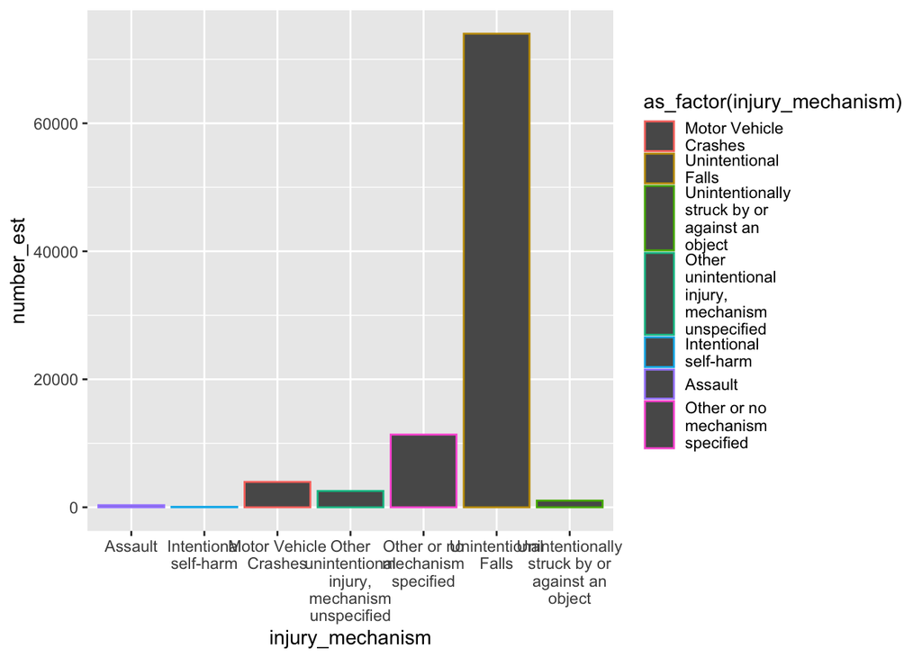

```r
#to cut the lenght of the variables we need to minimize the width of characters by line which makes them more readable chunck of code needs to be copied from solutions sheet
tbi_age$injury_mechanism <- str_wrap(tbi_age$injury_mechanism, width = 15)
oldest_hosp_plot <- tbi_age %>%
  filter(age_group == "75+" & type == "Hospitalizations") %>%
  ggplot(aes(x= injury_mechanism, y= number_est,colour = as_factor(injury_mechanism) )) +
  geom_col()



oldest_hosp_plot
```